# Weight Lifting Machine Learning

Nikhil Gupta

7/6/2017

## Summary

Objective of this anaysis is to predict the manner in which participant is exercising by assigning a classe variable to it. There are six partipants & five classes. Also, there are four measurements being taken from accelerometers on the belt, forearm, arm, & dumbbell. This entire analysis has been done in the following sequence:

1. Reading the csv file & filtering out the relevant predictors for the study
2. Partitioning the entire data in training & test data
3. Applying the K-Fold cross validation to each of the ensembling algorithm
4. Choosing different training methods(Single Decision Tree, Bagging, Random Forest, Generalized Additive Modelling) to find out the best accuracy model
5. Predicting the values of testing data with the arrived model using predictors values & attmepting final testing with the validation data(testing file)

# First Step:

Reading csv file. Eliminating the variables having NA & blank values. Then, choosing variables representing total acceleration on belt, forearm, arm & dumbbell. Below mentioned is the header of main data frame to be analyzed.

```
##   user_name total_accel_belt total_accel_arm total_accel_dumbbell
## 1  carlitos                3              34                   37
## 2  carlitos                3              34                   37
## 3  carlitos                3              34                   37
## 4  carlitos                3              34                   37
## 5  carlitos                3              34                   37
## 6  carlitos                3              34                   37
##   total_accel_forearm classe
## 1                  36      A
## 2                  36      A
## 3                  36      A
## 4                  36      A
## 5                  36      A
## 6                  36      A
```

# Second Step:

Loading suitable libraries. Also, partitioning data into training & test set in the ratio of 0.75 using Data Partition fucntion.

# Third Step:

Using rpart to predict using decision tree. Plot the decision tree & evaluate the accuracy of the predictions made by it.

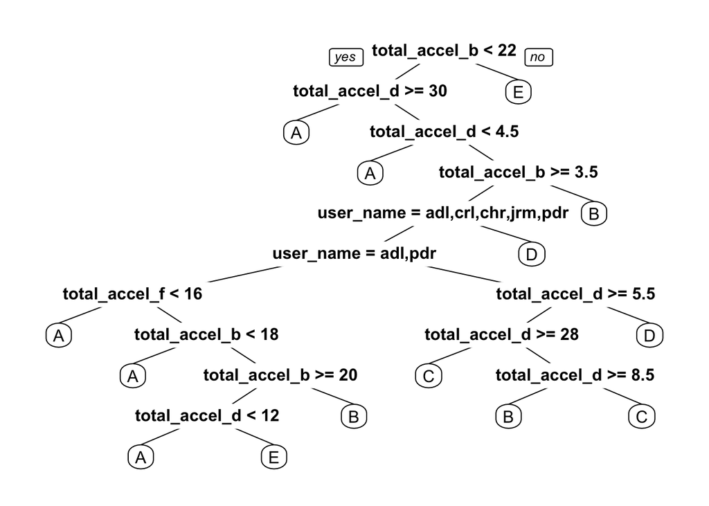

```r
fit <- rpart(training$classe ~.,method="class", data=training)
rpart.plot::prp(fit)
```

```r
predict_values_training=predict(fit, training,type = "class")
accuracy_training = sum(predict_values_training == training$classe)/length(predict_values_training)

predict_values_testing=predict(fit, testing,type = "class")
accuracy_testing = sum(predict_values_testing == testing$classe)/length(predict_values_testing)
cat("Accuracy in the testing data","\n")
```

```
## Accuracy in the testing data
```

```r
print(accuracy_testing)
```

```
## [1] 0.4622757
```

# Fourth Step:

Random forest predicion by incorporating 10 fold cross validation in the train function without any pre-processing of data.Exhibit the confusion matrix & evaluate the accuracy of the predictions made by it.

```
## Confusion Matrix and Statistics
##
##           Reference
## Prediction    A    B    C    D    E
##          A 1114  107   95   76   42
##          B   68  593   70   53   69
##          C  100  118  588  113   41
##          D   93   75   77  537   54
##          E   20   56   25   25  695
##
## Overall Statistics
##
##                Accuracy : 0.7192
##                  95% CI : (0.7064, 0.7318)
##     No Information Rate : 0.2845
##     P-Value [Acc > NIR] : < 2.2e-16
##
##                   Kappa : 0.6447
##  Mcnemar's Test P-Value : 1.293e-08
##
## Statistics by Class:
##
##                      Class: A Class: B Class: C Class: D Class: E
## Sensitivity            0.7986   0.6249   0.6877   0.6679   0.7714
## Specificity            0.9088   0.9343   0.9081   0.9271   0.9685
## Pos Pred Value         0.7768   0.6952   0.6125   0.6423   0.8465
## Neg Pred Value         0.9190   0.9121   0.9323   0.9344   0.9495
## Prevalence             0.2845   0.1935   0.1743   0.1639   0.1837
## Detection Rate         0.2272   0.1209   0.1199   0.1095   0.1417
## Detection Prevalence   0.2924   0.1739   0.1958   0.1705   0.1674
## Balanced Accuracy      0.8537   0.7796   0.7979   0.7975   0.8699
```

```
##
## Call:
##  randomForest(x = x, y = y, mtry = param$mtry)
##                Type of random forest: classification
##                      Number of trees: 500
## No. of variables tried at each split: 5
##
##         OOB estimate of  error rate: 27.16%
## Confusion matrix:
##      A    B    C    D    E class.error
## A 3453  150  260  277   45   0.1749104
## B  299 1779  387  192  191   0.3753511
## C  252  223 1756  249   87   0.3159330
## D  269  117  344 1587   95   0.3420398
## E   83  207  145  126 2145   0.2073171
```

# Fifth Step:

Bagging emsembling method was attempted in the train function without any pre-processing of data.Exhibiting the results & evaluating the accuracy of the predictions made by it.

```
## Confusion Matrix and Statistics
##
##           Reference
## Prediction   A   B   C   D   E
##          A 979 558 552 463 326
##          B 100 228  52  20 115
##          C  98  53 109  75  51
##          D 188  92 134 164  78
##          E  30  18   8  82 331
##
## Overall Statistics
##
##                Accuracy : 0.3693
##                  95% CI : (0.3558, 0.383)
##     No Information Rate : 0.2845
##     P-Value [Acc > NIR] : < 2.2e-16
##
##                   Kappa : 0.1696
##  Mcnemar's Test P-Value : < 2.2e-16
##
## Statistics by Class:
##
##                      Class: A Class: B Class: C Class: D Class: E
## Sensitivity            0.7018  0.24025  0.12749  0.20398  0.36737
## Specificity            0.4588  0.92743  0.93159  0.88000  0.96553
## Pos Pred Value         0.3402  0.44272  0.28238  0.25000  0.70576
## Neg Pred Value         0.7947  0.83573  0.83488  0.84934  0.87148
## Prevalence             0.2845  0.19352  0.17435  0.16395  0.18373
## Detection Rate         0.1996  0.04649  0.02223  0.03344  0.06750
## Detection Prevalence   0.5869  0.10502  0.07871  0.13377  0.09564
## Balanced Accuracy      0.5803  0.58384  0.52954  0.54199  0.66645
```

# Sixth Step:

Predictive modelling using Generalized Addtive Models(GAM) method was attempted in the train function without any pre-processing of data.Exhibiting the results & evaluating the accuracy of the predictions made by it.

[output not shown]